# Hit Probabilities & Valuing Hitters

In this installment of baseball research, I'm going to try fitting some different machine learning algorithms to predict the outcome of a batted ball based on things like its speed and trajectory. I'll test their accuracy and ultimately settle on a most effective model.

### Modern Player Evaluation

A big part of modern baseball player evaluation is measuring players on things they have control over instead of on overall outcomes. When a hitter is up to the plate, one of the biggest things he's responsible for is hitting the ball hard and at a favorable trajectory. From the hitter's point of view, the outcome of a play can be affected by luck -- like a particularly talented fielder turning a likely hit into an out, or wind pushing routine flyout over the fence. If we strip these things out, it should be possible to uncover a hitter's *true* talent.

I'm going to use a hitter's batted-ball data to try to uncover their true talent. That is, trying to predict what *should* have happened based only on the hitter's contributions -- how hard they hit the ball and where.

### Model Building

My goal here isn't necessarily to predict the outcome of a hit as accurately as possible. I'm intentionally leaving out features that would provide context, like the stadium, the fielding team, or the relevant fielder, because the batter has no control over them. I'll try a more descriptive model in another writeup.

If I'm trying to uncover a hitter's true talent, I'll build models using only the things the hitter is responsible for:

- batted ball speed
- batted ball vertical angle (launch angle)
- batted ball spray angle (direction/horizontal angle)
- batter handedness

As far as the models themselves go, I mostly care about the *probabilistic* predictions from each model. I can get the outcome classification from that data, but more importantly, those probabilities are useful. If we assign a value to the results of a batted ball, we can calculate the expected value of the batted ball and use that to value a hitter.

Before I start fitting any models, I actually need to calculate the batted ball spray angle myself. I'm using data that I previously calibrated to remove any stadium measurement bias ([writeup here](https://github.com/jonahkrop/baseball-projects/blob/master/statcast_calibrations.html)).

```
/Users/JonahKrop/Documents/Projects/Baseball
```

```python
import pandas as pd
import numpy as np
import seaborn as sns
import matplotlib.pyplot as plt
import time as time

from sklearn.linear_model import LinearRegression
```

```python
df_2016 = pd.read_csv('mlb_2016_adjusted.csv')
df_2017 = pd.read_csv('mlb_2017_adjusted.csv')
df_2018 = pd.read_csv('mlb_2018_adjusted.csv')
df_2019 = pd.read_csv('mlb_2019_adjusted.csv')

df = pd.concat([df_2016, df_2017, df_2018, df_2019], axis=0)

# filter to clean readings of batted balls
df = df.dropna(subset=['launch_speed', 'launch_angle', 'hc_x', 'hc_y']).reset_index(drop=True)

print('Total batted-ball sample: %s' %len(df))

# save some memory
del df_2016
del df_2017
del df_2018
del df_2019
```

```
Total batted-ball sample: 505089
```

## Calculating spray angle

Statcast directly provides the batted ball speed and vertical launch angle, but doesn't give the spray angle. What it does give is the `hc_x` and `hc_y`, which correspond to the `x` and `y` coordinate positions where the ball either landed or was fielded. This doesn't *exactly* give the horizontal angle at which the ball was batted, since wind or ball spin can change the trajectory of the ball mid-air, but it should be pretty close. Let's check out what that data looks like.

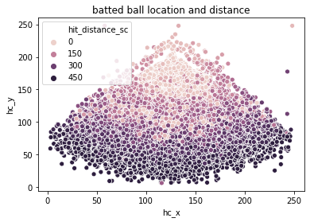

Huh. So, it turns out `hc_x` and `hc_y` aren't centered with (0,0) at home plate, nor are they in units of feet. I dug around a little, and according to [this document](https://developer.sportradar.com/files/Sportradar_MLB_v7_with_Statcast_Statistics_Feeds.pdf), they're defined as

> Coordinates entered by operator in pressbox of where the ball is fielded. Based on 250x250 field graphic, where 0,0 is in the upper left corner, in very deep left field, and 250,250 is in the lower right corner, in foul territory between 1B and home plate. The fields are centered in that space, the x=125 axis runs through the middle of 2B, the pitcher’s mound and home plate; the 1B and 3B bases are roughly aligned on the y=175 line.

Ok, fine. So I'll put it into a normal coordinate system. The x-coordinate is easy enough to transform, I'll just subtract 125 from each entry. For the y-coordinate, I'll filter to balls hit straight up the middle of the field (x=125), where the batted ball distance should be equal to the y-coordinate distance. If I fit a linear regression between the hit distance and the y-coordinate for balls where x=125, then I'll be able to zero-out the y coordinate *and* get the transformation from pixel units to feet!

One thing to check -- The document above says `hit_distance_sc` measures the distance traveled by the ball, and `hc_x` and `hc_y` measure distance until the ball was fielded. On groundballs, `hit_distance_sc` might report a distance right in front of home plate and `hc_x` and `hc_y` might report a distance somewhere in the infield.

I'll just plot `hc_y` against `hit_distance_sc` with the hit type and see what's what.

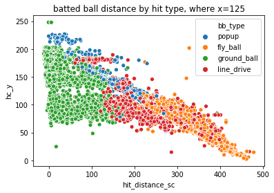

Yep, so that's actually a problem. Ground balls and some line drives have further registered distances by `hc_y` (it's confusing, lower numbers are further) than the `hit_distance_sc`. All this means is that I'll just filter out ground balls and line drives when I regress `hc_y` and `hit_distance_sc`.

```python
df_adj = df.copy(deep=True)

# zero hc_x
df_adj['hc_x'] = df_adj.hc_x - 125

# get non ground-balls and line-drives hit up the middle
df_0 = df_adj[(df_adj.hc_x >= -1) &
              (df_adj.hc_x <= 1) &
              (df_adj.bb_type != 'ground_ball') &
              (df_adj.bb_type != 'line_drive')]

df_0 = df_0.dropna(subset=['hit_distance_sc']).reset_index(drop=True)

X = df_0[['hit_distance_sc']]
y = df_0['hc_y']

y_mod = LinearRegression().fit(X, y)

print('y-coord translation = %0.3f' % y_mod.intercept_)
print('pixel-feet conversion factor = %0.3f' % y_mod.coef_[0])

# transform y-coords so home plate is at y=0 and larger = further
df_adj['hc_y'] = (-1 * df_adj['hc_y']) + y_mod.intercept_

# apply conversion from pixels to feet
df_adj['hc_x'] = df_adj['hc_x'] / abs(y_mod.coef_[0])
df_adj['hc_y'] = df_adj['hc_y'] / abs(y_mod.coef_[0])
```

```
y-coord translation = 212.726
pixel-feet conversion factor = -0.452
```

Looking back at the first plot, this passes the eye test. The y-coord translation means home plate is located at about y=213, which matches up with that plot. I'll divide `hc_x` and `hc_y` by 0.45 to convert to feet. Now that I have the right units, I'll calculate the spray angle.

Let's remake that first plot to make sure we've successfully transformed the data, and I'll add another plot to make sure the direction angle makes sense.

```python
# calculate the horizontal angle based on hc_x and hc_y
def calc_horz_angle(data):
    hcx = data['hc_x']
    hcy = data['hc_y']

    if (hcx >= 0 and hcy >= 0) | (hcx < 0 and hcy >= 0):
        horz = np.rad2deg(np.arctan(hcx / hcy))

    elif hcx >= 0 and hcy < 0:
        horz = np.rad2deg(np.arctan(abs(hcx / hcy))) + 90

    elif hcx < 0 and hcy < 0:
        horz = -np.rad2deg(np.arctan(hcx / hcy)) - 90

    else:
        horz = np.nan

    return horz

df_adj['horz_angle'] = df_adj.apply(calc_horz_angle, axis=1)
```

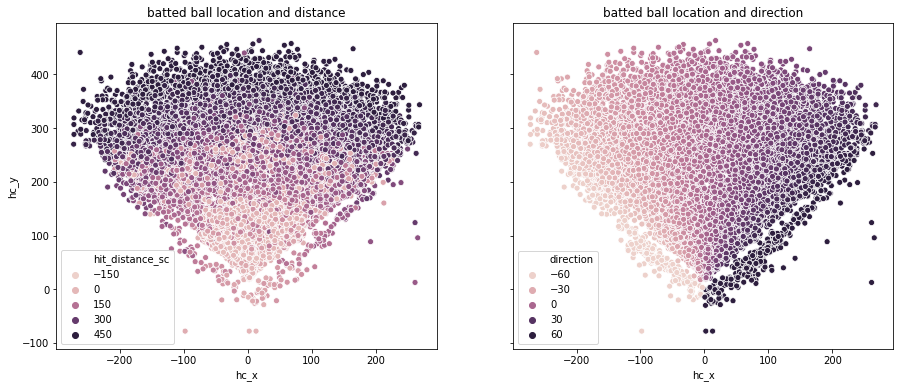

Nice! I'm ready to move on to testing some models.

## Predicting outcomes

I don't need a whole lot of information for these models: the four features I mentioned above, plus the outcome of the play. There's a few adjustments we need to make:

1) Remove any bunts from the dataset  
2) map non-hit outcomes to 'out' (Statcast elaborates on the out type, e.g. sacrifice fly, fielders choice)  
3) One-hot encode batter handedness

```python
# stand = handedness
cols = ['events', 'stand', 'launch_speed', 'launch_angle', 'direction']

df_mod = df_adj[cols]

# 1) drop bunts
df_mod = df_mod[~df_mod['events'].isin(['sac_bunt', 'sac_bunt_double_play'])]

# 2) anything that's not a hit = out
df_mod.loc[~df_mod['events'].isin(
    ['single', 'double', 'triple', 'home_run']), 'events'] = 'out'

# 3) one-hot encode handedness
df_mod = pd.concat([df_mod, pd.get_dummies(df_mod.stand)], axis=1)

# drop unecessary columns & rename to be a little clearer
df_mod = df_mod.drop(columns=['stand', 'L'])
df_mod = df_mod.rename(columns={'R': 'is_Right'})
```

### Oversampling?

There's one other consideration worth making -- the distribution of outcomes of a batted ball is somewhat imbalanced. Singles and even doubles occur frequently enough compared to outs, but triples are pretty uncommon. I might try an oversampling technique to see how it affects the models. Oversampling techniques are usually applied to datasets where an outcome is significantly less common, like with credit card fraud. That might be a little bit of a stretch for this scenario, but I think it's worth at least checking if an oversampling technique would help.

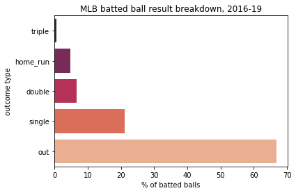

I'll try fitting my different models twice -- with and without oversampling. For oversampling, I'm going to use **SMOTE** (synthetic minority oversampling technique) using the `imblearn` package.

Here's what SMOTE does to a sample of data.

```python
from imblearn.over_sampling import SMOTE

s = df_mod.sample(n=20000).reset_index(drop=True)

X = s[['launch_speed', 'launch_angle', 'direction', 'is_Right']]
y = s['events']

# perform resampling
sm = SMOTE()
X, y = sm.fit_resample(X, y)

print('Total oversampled data: %s' % len(y))
```

```
Total oversampled data: 66420
```

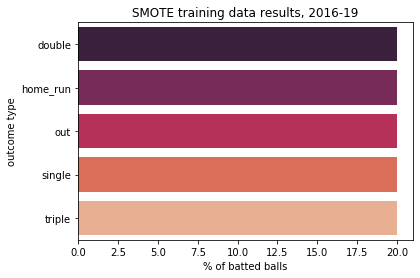

## Model Building

With or without SMOTE, I've settled on 6 popular classifiers to compare. I'll use:

- logistic regression
- k-nearest neighbors
- support vector machine
- decision tree
- random forest
- gradient boosting

And I'm going to use 4 metrics to evaluate the models, which together should give a good picture of the best overall model:

- F1 score (weighted by instances of each label)
- ROC AUC (computed by label and weighted by frequency)
- balanced accuracy (for imbalanced datasets)
- log loss

I'll run with largely default settings for each of the models to keep a relatively level playing field. For runtime considerations, I'm going to use a relatively pared down sample size of data. Once I pick the best model, I'll do some parameter tuning in another writeup.

```python
from imblearn.pipeline import Pipeline
from sklearn.preprocessing import StandardScaler
from sklearn.model_selection import cross_validate
from sklearn.metrics import f1_score, accuracy_score, log_loss, roc_auc_score, make_scorer

from sklearn.linear_model import LogisticRegression
from sklearn.neighbors import KNeighborsClassifier
from sklearn.svm import SVC
from sklearn.tree import DecisionTreeClassifier
from sklearn.ensemble import RandomForestClassifier, GradientBoostingClassifier

# scoring metrics
scoring = {
    'f1_weighted': 'f1_weighted',
    'accuracy': 'balanced_accuracy',
    'roc_auc': 'roc_auc_ovr_weighted',
    'neg_log_loss': 'neg_log_loss'
    }

# for results df
eval_cols = [
    'models',
    'F1 Score',
    'Balanced Accuracy',
    'ROC AUC',
    'Neg Log Loss'
    ]

# define classifier models
classifiers = [
    LogisticRegression(multi_class='multinomial'),
    KNeighborsClassifier(n_neighbors=50),
    SVC(probability=True),
    DecisionTreeClassifier(),
    RandomForestClassifier(),
    GradientBoostingClassifier()
    ]

# classifier names
clf_names = [
    'Logistic Regression',
    'KNN',
    'SVM',
    'Decision Tree',
    'Random Forest',
    'Gradient Boosting'
    ]

# use sample so this doesn't take forever
s = df_mod.sample(n=20000).reset_index(drop=True)

# scale and center numeric columns
to_scale = ['launch_speed', 'launch_angle', 'direction']
s[to_scale] = StandardScaler().fit_transform(s[to_scale])

X = s[['launch_speed', 'launch_angle', 'direction', 'is_Right']]
y = s['events']
```

### 1) Model Building with SMOTE

First, I'll try my models with SMOTE applied to the training data.

I'm going to rely on the `imblearn` package again to set up a pipeline for cross-validating the models. If I'm going to oversample the data, it's important that I train on the oversampled data and then validate/test on the standard data. `imblearn`'s pipeline is set up to apply oversampling just to the training data and then validate/test on the unsampled data.

```python
f1, acc, roc_auc, log_loss = [], [], [], []
for clf, clf_nm in zip(classifiers, clf_names):

    # setup pipeline to oversample, then fit model
    pipe = Pipeline([
        ('smote', SMOTE()),
        ('classify', clf)
        ])

    start = time.time()

    # cross-validate 5 times
    res_smote = cross_validate(pipe, X, y, cv=5, scoring=scoring)
    results_smote = pd.DataFrame(res_smote)

    stop = time.time()

    print('Time to cross-validate %s = %0.3f min.' % (clf_nm, (stop - start) / 60))

    # save average scores
    f1.append(np.mean(results_smote.test_f1_weighted))
    acc.append(np.mean(results_smote.test_accuracy))
    roc_auc.append(np.mean(results_smote.test_roc_auc))
    log_loss.append(np.mean(results_smote.test_neg_log_loss))

# save results to df
model_eval_smote = pd.DataFrame(data=zip(clf_names, f1, acc, roc_auc, log_loss),
                          columns=eval_cols)

display(model_eval_smote)
```

```
Time to cross-validate Logistic Regression = 0.088 min.
Time to cross-validate KNN = 0.057 min.
Time to cross-validate SVM = 75.796 min.
Time to cross-validate Decision Tree = 0.040 min.
Time to cross-validate Random Forest = 0.786 min.
Time to cross-validate Gradient Boosting = 22.067 min.
```

|  | models | F1 Score | Balanced Accuracy | ROC AUC | Neg Log Loss |
| --- | --- | --- | --- | --- | --- |
| 0 | Logistic Regression | 0.358424 | 0.427945 | 0.631888 | -1.356483 |
| 1 | KNN | 0.714239 | 0.638177 | 0.878989 | -1.456460 |
| 2 | SVM | 0.688256 | 0.641060 | 0.863649 | -0.779304 |
| 3 | Decision Tree | 0.719102 | 0.559454 | 0.755783 | -10.334002 |
| 4 | Random Forest | 0.756999 | 0.609654 | 0.884364 | -0.974280 |
| 5 | Gradient Boosting | 0.725057 | 0.670066 | 0.880659 | -0.745289 |

### 2) Model Building without SMOTE

Basically the same process here, except without oversampling, so I won't need the pipeline. I'll just drop each model into `sklearn`'s `cross_validate` and compare the scores.

```python
f1, acc, roc_auc, log_loss = [], [], [], []
for clf, clf_nm in zip(classifiers, clf_names):

    start = time.time()

    # cross-validate 5 times
    res = cross_validate(clf, X, y, cv=5, scoring=scoring)
    results = pd.DataFrame(res)

    stop = time.time()

    print('Time to cross-validate %s = %0.3f min.' % (clf_nm, (stop - start) / 60))

    # save average scores
    f1.append(np.mean(results.test_f1_weighted))
    acc.append(np.mean(results.test_accuracy))
    roc_auc.append(np.mean(results.test_roc_auc))
    log_loss.append(np.mean(results.test_neg_log_loss))

# save results to df
model_eval = pd.DataFrame(data=zip(clf_names, f1, acc, roc_auc, log_loss),
                          columns=eval_cols)

display(model_eval)
```

```
Time to cross-validate Logistic Regression = 0.042 min.
Time to cross-validate KNN = 0.032 min.
Time to cross-validate SVM = 2.258 min.
Time to cross-validate Decision Tree = 0.013 min.
Time to cross-validate Random Forest = 0.235 min.
Time to cross-validate Gradient Boosting = 0.805 min.
```

|  | models | F1 Score | Balanced Accuracy | ROC AUC | Neg Log Loss |
| --- | --- | --- | --- | --- | --- |
| 0 | Logistic Regression | 0.560356 | 0.274831 | 0.683531 | -0.819763 |
| 1 | KNN | 0.782269 | 0.517114 | 0.900268 | -0.656604 |
| 2 | SVM | 0.750390 | 0.493691 | 0.870527 | -0.566094 |
| 3 | Decision Tree | 0.723697 | 0.490708 | 0.730431 | -9.568968 |
| 4 | Random Forest | 0.782306 | 0.535882 | 0.894031 | -0.732715 |
| 5 | Gradient Boosting | 0.780840 | 0.528948 | 0.896785 | -0.529500 |

## Summing Up

Overall, the gradient boosting model was the best. The SVM was also quite good, but slightly worse in general and easily the slowest model to fit (related to forcing probabilistic output).

With that, it looks like the gradient boosting model with regularly sampled data is the way to go. I have a few follow-ups to this reports I'd like to do:

- including contextual data for modeling outcomes as accurately as possible
- performing some parameter tuning on the gradient boosting model
- using hit probabilities and predicted outcomes to value hitters

I'll link them here once they're done!